# **Problem Statement**

## Model 1: Simple Convolutional Neural Network (CNN)

Let's build a **CNN Model**.

The model has 2 main parts:

1. **The Feature Extraction layers** which are comprised of convolutional and pooling layers.
2. **The Fully Connected classification layers for prediction.**

```python
# Initializing Model
model_1 = Sequential()

# Convolutional layers
model_1.add(Conv2D(32, (3, 3), activation='relu', padding="same", input_shape=(200,200,3)))
model_1.add(MaxPooling2D((4, 4), padding='same'))
model_1.add(Conv2D(64, (3, 3), activation='relu', padding="same"))
model_1.add(MaxPooling2D((4,4), padding='same'))
model_1.add(Conv2D(128, (3,3), activation='relu', padding="same"))

# Flatten and Dense layers
model_1.add(Flatten())
model_1.add(Dense(4, activation='relu'))
model_1.add(Dense(1, activation='sigmoid'))

# Compile with Adam Optimizer
opt = Adam(learning_rate=0.001)
model_1.compile(optimizer=opt, loss='binary_crossentropy', metrics=["accuracy","recall"])

# Summary
model_1.summary()
```

```
Model: "sequential_14"
```

```
┏━━━━━━━━━━━━━━━━━━━━━━━━━━━━━━━━━┳━━━━━━━━━━━━━━━━━━━━━━━━┳━━━━━━━━━━━━━━━┓
┃ Layer (type)                    ┃ Output Shape           ┃       Param # ┃
┡━━━━━━━━━━━━━━━━━━━━━━━━━━━━━━━━━╇━━━━━━━━━━━━━━━━━━━━━━━━╇━━━━━━━━━━━━━━━┩
│ conv2d_33 (Conv2D)              │ (None, 200, 200, 32)   │           896 │
├─────────────────────────────────┼────────────────────────┼───────────────┤
│ max_pooling2d_22 (MaxPooling2D) │ (None, 50, 50, 32)     │             0 │
├─────────────────────────────────┼────────────────────────┼───────────────┤
│ conv2d_34 (Conv2D)              │ (None, 50, 50, 64)     │        18,496 │
├─────────────────────────────────┼────────────────────────┼───────────────┤
│ max_pooling2d_23 (MaxPooling2D) │ (None, 13, 13, 64)     │             0 │
├─────────────────────────────────┼────────────────────────┼───────────────┤
│ conv2d_35 (Conv2D)              │ (None, 13, 13, 128)    │        73,856 │
├─────────────────────────────────┼────────────────────────┼───────────────┤
│ flatten_14 (Flatten)            │ (None, 21632)          │             0 │
├─────────────────────────────────┼────────────────────────┼───────────────┤
│ dense_25 (Dense)                │ (None, 4)              │        86,532 │
├─────────────────────────────────┼────────────────────────┼───────────────┤
│ dense_26 (Dense)                │ (None, 1)              │             5 │
└─────────────────────────────────┴────────────────────────┴───────────────┘
```

```
 Total params: 179,785 (702.29 KB)
```

```
 Trainable params: 179,785 (702.29 KB)
```

```
 Non-trainable params: 0 (0.00 B)
```

```python
history_1 = model_1.fit(
            X_train_normalized, y_train,
            epochs=20,
            validation_data=(X_val_normalized,y_val),
            shuffle=True,
            batch_size=128,
            verbose=2
)
```

```
5/5 - 5s - 1s/step - accuracy: 0.4903 - loss: 0.7235 - recall: 0.6559 - val_accuracy: 0.4912 - val_loss: 0.6932 - val_recall: 0.0000e+00
5/5 - 1s - 101ms/step - accuracy: 0.5079 - loss: 0.6931 - recall: 0.0000e+00 - val_accuracy: 0.4912 - val_loss: 0.6932 - val_recall: 0.0000e+00
5/5 - 0s - 88ms/step - accuracy: 0.5079 - loss: 0.6931 - recall: 0.0000e+00 - val_accuracy: 0.4912 - val_loss: 0.6932 - val_recall: 0.0000e+00
5/5 - 0s - 90ms/step - accuracy: 0.5079 - loss: 0.6931 - recall: 0.0000e+00 - val_accuracy: 0.4912 - val_loss: 0.6932 - val_recall: 0.0000e+00
5/5 - 0s - 91ms/step - accuracy: 0.5079 - loss: 0.6931 - recall: 0.0000e+00 - val_accuracy: 0.4912 - val_loss: 0.6932 - val_recall: 0.0000e+00
5/5 - 1s - 101ms/step - accuracy: 0.5079 - loss: 0.6931 - recall: 0.0000e+00 - val_accuracy: 0.4912 - val_loss: 0.6932 - val_recall: 0.0000e+00
5/5 - 1s - 133ms/step - accuracy: 0.5079 - loss: 0.6931 - recall: 0.0000e+00 - val_accuracy: 0.4912 - val_loss: 0.6932 - val_recall: 0.0000e+00
5/5 - 1s - 110ms/step - accuracy: 0.5079 - loss: 0.6931 - recall: 0.0000e+00 - val_accuracy: 0.4912 - val_loss: 0.6932 - val_recall: 0.0000e+00
5/5 - 1s - 108ms/step - accuracy: 0.5079 - loss: 0.6931 - recall: 0.0000e+00 - val_accuracy: 0.4912 - val_loss: 0.6932 - val_recall: 0.0000e+00
5/5 - 1s - 113ms/step - accuracy: 0.5079 - loss: 0.6931 - recall: 0.0000e+00 - val_accuracy: 0.4912 - val_loss: 0.6932 - val_recall: 0.0000e+00
5/5 - 1s - 104ms/step - accuracy: 0.5079 - loss: 0.6931 - recall: 0.0000e+00 - val_accuracy: 0.4912 - val_loss: 0.6932 - val_recall: 0.0000e+00
5/5 - 0s - 87ms/step - accuracy: 0.5079 - loss: 0.6931 - recall: 0.0000e+00 - val_accuracy: 0.4912 - val_loss: 0.6932 - val_recall: 0.0000e+00
5/5 - 0s - 91ms/step - accuracy: 0.5079 - loss: 0.6931 - recall: 0.0000e+00 - val_accuracy: 0.4912 - val_loss: 0.6932 - val_recall: 0.0000e+00
5/5 - 0s - 91ms/step - accuracy: 0.5079 - loss: 0.6931 - recall: 0.0000e+00 - val_accuracy: 0.4912 - val_loss: 0.6932 - val_recall: 0.0000e+00
5/5 - 0s - 93ms/step - accuracy: 0.5079 - loss: 0.6931 - recall: 0.0000e+00 - val_accuracy: 0.4912 - val_loss: 0.6932 - val_recall: 0.0000e+00
5/5 - 0s - 91ms/step - accuracy: 0.5079 - loss: 0.6931 - recall: 0.0000e+00 - val_accuracy: 0.4912 - val_loss: 0.6932 - val_recall: 0.0000e+00
5/5 - 0s - 96ms/step - accuracy: 0.5079 - loss: 0.6931 - recall: 0.0000e+00 - val_accuracy: 0.4912 - val_loss: 0.6933 - val_recall: 0.0000e+00
5/5 - 0s - 93ms/step - accuracy: 0.5079 - loss: 0.6931 - recall: 0.0000e+00 - val_accuracy: 0.4912 - val_loss: 0.6933 - val_recall: 0.0000e+00
5/5 - 0s - 91ms/step - accuracy: 0.5079 - loss: 0.6931 - recall: 0.0000e+00 - val_accuracy: 0.4912 - val_loss: 0.6933 - val_recall: 0.0000e+00
5/5 - 0s - 92ms/step - accuracy: 0.5079 - loss: 0.6931 - recall: 0.0000e+00 - val_accuracy: 0.4912 - val_loss: 0.6933 - val_recall: 0.0000e+00
```

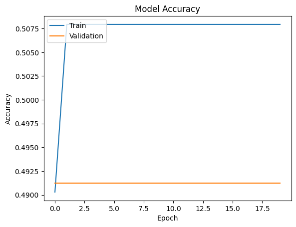

```python
plt.plot(history_1.history['accuracy'])
plt.plot(history_1.history['val_accuracy'])
plt.title('Model Accuracy')
plt.ylabel('Accuracy')
plt.xlabel('Epoch')
plt.legend(['Train', 'Validation'], loc='upper left')
plt.show()
```

```python
model_1_train_perf = model_performance_classification(model_1, X_train_normalized,y_train)

print("Train performance metrics")
print(model_1_train_perf)
```

```
18/18 ━━━━━━━━━━━━━━━━━━━━ 1s 49ms/step
Train performance metrics
   Accuracy    Recall  Precision  F1 Score
0  0.507937  0.507937   0.257999  0.342189
```

```
18/18 ━━━━━━━━━━━━━━━━━━━━ 0s 12ms/step
```

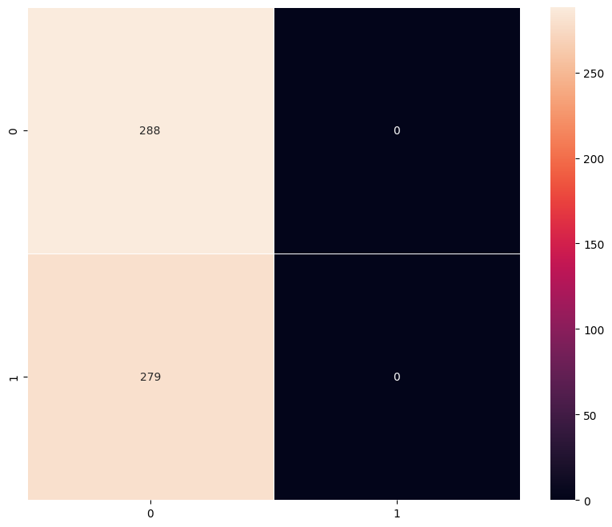

```python
plot_confusion_matrix(model_1,X_train_normalized,y_train)
```

```python
model_1_valid_perf = model_performance_classification(model_1, X_val_normalized,y_val)

print("Validation performance metrics")
print(model_1_valid_perf)
```

```
2/2 ━━━━━━━━━━━━━━━━━━━━ 0s 411ms/step
Validation performance metrics
   Accuracy    Recall  Precision  F1 Score
0  0.491228  0.491228   0.241305  0.323633
```

```
2/2 ━━━━━━━━━━━━━━━━━━━━ 0s 22ms/step
```

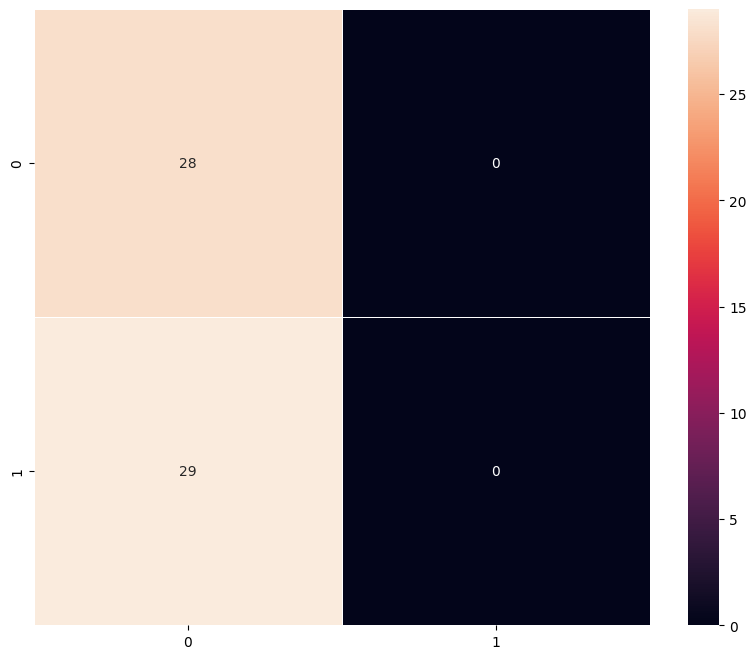

```python
plot_confusion_matrix(model_1,X_val_normalized,y_val)
```

### Vizualizing the predictions

```
1/1 ━━━━━━━━━━━━━━━━━━━━ 1s 510ms/step
Predicted Label: 0
True Label: Label    1
Name: 567, dtype: int64
```

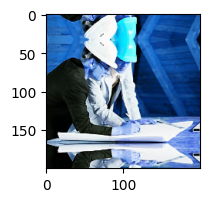

```
1/1 ━━━━━━━━━━━━━━━━━━━━ 0s 31ms/step
Predicted Label: 0
True Label: Label    1
Name: 17, dtype: int64
```

```python
plt.figure(figsize=(2,2))
plt.imshow(X_val[5])
plt.show()
prediction = model_1.predict(X_val_normalized[5].reshape(1,200,200,3))
predicted_label = prediction[0][0]>0.5
print('Predicted Label:', 1 if predicted_label else 0)
# Fix indexing issue in y_val
true_label = y_val.iloc[5]
print('True Label:', true_label)

plt.figure(figsize=(2,2))
plt.imshow(X_val[50])
plt.show()
prediction = model_1.predict(X_val_normalized[50].reshape(1,200,200,3))
predicted_label = prediction[0][0]>0.5
print('Predicted Label:', 1 if predicted_label else 0)
# Fix indexing issue in y_val
true_label = y_val.iloc[50]
print('True Label:', true_label)
```

##### Observations

- With the simple CNN, we can notice that the accuracy of the model is 50% accuracy all the epochs. Even, the recall score is almost 0 so this is not accurate and lets evalute with different approaches.
- Clearly, we can visualize the predications where it predicted the it is without helmet but actually the image is with the helmet(predicted label:0, true label: 1).
- Here, the recall score is completely 0. So, cant used this model at all for further predictions. Lets analyse the remaining approaches.

## Model 2: (VGG-16 (Base))

- We will be loading a pre-built architecture - **VGG16**, which was trained on the ImageNet dataset and is the runner-up in the ImageNet competition in 2014.
- For training VGG16, we will directly use the convolutional and pooling layers and freeze their weights i.e. no training will be done on them. For classification, we will add a Flatten and a single dense layer.

```python
vgg_model = VGG16(weights='imagenet',include_top=False,input_shape=(200,200,3))
vgg_model.summary()
```

```
Model: "vgg16"
```

```
┏━━━━━━━━━━━━━━━━━━━━━━━━━━━━━━━━━┳━━━━━━━━━━━━━━━━━━━━━━━━┳━━━━━━━━━━━━━━━┓
┃ Layer (type)                    ┃ Output Shape           ┃       Param # ┃
┡━━━━━━━━━━━━━━━━━━━━━━━━━━━━━━━━━╇━━━━━━━━━━━━━━━━━━━━━━━━╇━━━━━━━━━━━━━━━┩
│ input_layer_18 (InputLayer)     │ (None, 200, 200, 3)    │             0 │
├─────────────────────────────────┼────────────────────────┼───────────────┤
│ block1_conv1 (Conv2D)           │ (None, 200, 200, 64)   │         1,792 │
├─────────────────────────────────┼────────────────────────┼───────────────┤
│ block1_conv2 (Conv2D)           │ (None, 200, 200, 64)   │        36,928 │
├─────────────────────────────────┼────────────────────────┼───────────────┤
│ block1_pool (MaxPooling2D)      │ (None, 100, 100, 64)   │             0 │
├─────────────────────────────────┼────────────────────────┼───────────────┤
│ block2_conv1 (Conv2D)           │ (None, 100, 100, 128)  │        73,856 │
├─────────────────────────────────┼────────────────────────┼───────────────┤
│ block2_conv2 (Conv2D)           │ (None, 100, 100, 128)  │       147,584 │
├─────────────────────────────────┼────────────────────────┼───────────────┤
│ block2_pool (MaxPooling2D)      │ (None, 50, 50, 128)    │             0 │
├─────────────────────────────────┼────────────────────────┼───────────────┤
│ block3_conv1 (Conv2D)           │ (None, 50, 50, 256)    │       295,168 │
├─────────────────────────────────┼────────────────────────┼───────────────┤
│ block3_conv2 (Conv2D)           │ (None, 50, 50, 256)    │       590,080 │
├─────────────────────────────────┼────────────────────────┼───────────────┤
│ block3_conv3 (Conv2D)           │ (None, 50, 50, 256)    │       590,080 │
├─────────────────────────────────┼────────────────────────┼───────────────┤
│ block3_pool (MaxPooling2D)      │ (None, 25, 25, 256)    │             0 │
├─────────────────────────────────┼────────────────────────┼───────────────┤
│ block4_conv1 (Conv2D)           │ (None, 25, 25, 512)    │     1,180,160 │
├─────────────────────────────────┼────────────────────────┼───────────────┤
│ block4_conv2 (Conv2D)           │ (None, 25, 25, 512)    │     2,359,808 │
├─────────────────────────────────┼────────────────────────┼───────────────┤
│ block4_conv3 (Conv2D)           │ (None, 25, 25, 512)    │     2,359,808 │
├─────────────────────────────────┼────────────────────────┼───────────────┤
│ block4_pool (MaxPooling2D)      │ (None, 12, 12, 512)    │             0 │
├─────────────────────────────────┼────────────────────────┼───────────────┤
│ block5_conv1 (Conv2D)           │ (None, 12, 12, 512)    │     2,359,808 │
├─────────────────────────────────┼────────────────────────┼───────────────┤
│ block5_conv2 (Conv2D)           │ (None, 12, 12, 512)    │     2,359,808 │
├─────────────────────────────────┼────────────────────────┼───────────────┤
│ block5_conv3 (Conv2D)           │ (None, 12, 12, 512)    │     2,359,808 │
├─────────────────────────────────┼────────────────────────┼───────────────┤
│ block5_pool (MaxPooling2D)      │ (None, 6, 6, 512)      │             0 │
└─────────────────────────────────┴────────────────────────┴───────────────┘
```

```
 Total params: 14,714,688 (56.13 MB)
```

```
 Trainable params: 14,714,688 (56.13 MB)
```

```
 Non-trainable params: 0 (0.00 B)
```

```python
# Making all the layers of the VGG model non-trainable. i.e. freezing them
for layer in vgg_model.layers:
    layer.trainable = False
```

```python
model_2 = Sequential()

# Adding the convolutional part of the VGG16 model from above
model_2.add(vgg_model)

# Flattening the output of the VGG16 model because it is from a convolutional layer
model_2.add(Flatten())

# Adding a dense output layer
model_2.add(Dense(1, activation='sigmoid'))
```

```python
opt=Adam(learning_rate=0.001)
# Compile model
model_2.compile(optimizer=opt, loss=keras.losses.BinaryCrossentropy(), metrics=["accuracy"])
```

```python
# Generating the summary of the model
model_2.summary()
```

```
Model: "sequential_16"
```

```
┏━━━━━━━━━━━━━━━━━━━━━━━━━━━━━━━━━┳━━━━━━━━━━━━━━━━━━━━━━━━┳━━━━━━━━━━━━━━━┓
┃ Layer (type)                    ┃ Output Shape           ┃       Param # ┃
┡━━━━━━━━━━━━━━━━━━━━━━━━━━━━━━━━━╇━━━━━━━━━━━━━━━━━━━━━━━━╇━━━━━━━━━━━━━━━┩
│ vgg16 (Functional)              │ (None, 6, 6, 512)      │    14,714,688 │
├─────────────────────────────────┼────────────────────────┼───────────────┤
│ flatten_16 (Flatten)            │ (None, 18432)          │             0 │
├─────────────────────────────────┼────────────────────────┼───────────────┤
│ dense_28 (Dense)                │ (None, 1)              │        18,433 │
└─────────────────────────────────┴────────────────────────┴───────────────┘
```

```
 Total params: 14,733,121 (56.20 MB)
```

```
 Trainable params: 18,433 (72.00 KB)
```

```
 Non-trainable params: 14,714,688 (56.13 MB)
```

```python
train_datagen = ImageDataGenerator()
```

```python
# Epochs
epochs = 20
# Batch size
batch_size = 128

history_2 = model_2.fit(train_datagen.flow(X_train_normalized,y_train,
                                      batch_size=batch_size,
                                      seed=42,
                                      shuffle=False),
                    epochs=epochs,
                    steps_per_epoch=X_train_normalized.shape[0] // batch_size,
                    validation_data=(X_val_normalized,y_val),
                    verbose=1)
```

```
4/4 ━━━━━━━━━━━━━━━━━━━━ 8s 2s/step - accuracy: 1.0000 - loss: 6.5689e-07 - val_accuracy: 1.0000 - val_loss: 2.8767e-05
4/4 ━━━━━━━━━━━━━━━━━━━━ 1s 154ms/step - accuracy: 1.0000 - loss: 1.1786e-06 - val_accuracy: 1.0000 - val_loss: 3.3895e-05
4/4 ━━━━━━━━━━━━━━━━━━━━ 2s 669ms/step - accuracy: 1.0000 - loss: 6.5168e-07 - val_accuracy: 1.0000 - val_loss: 3.3873e-05
4/4 ━━━━━━━━━━━━━━━━━━━━ 1s 222ms/step - accuracy: 1.0000 - loss: 5.1033e-07 - val_accuracy: 1.0000 - val_loss: 3.1355e-05
4/4 ━━━━━━━━━━━━━━━━━━━━ 3s 636ms/step - accuracy: 1.0000 - loss: 5.8898e-07 - val_accuracy: 1.0000 - val_loss: 2.4714e-05
4/4 ━━━━━━━━━━━━━━━━━━━━ 1s 113ms/step - accuracy: 1.0000 - loss: 4.0059e-07 - val_accuracy: 1.0000 - val_loss: 2.4583e-05
4/4 ━━━━━━━━━━━━━━━━━━━━ 2s 561ms/step - accuracy: 1.0000 - loss: 5.3736e-07 - val_accuracy: 1.0000 - val_loss: 2.8486e-05
4/4 ━━━━━━━━━━━━━━━━━━━━ 1s 112ms/step - accuracy: 1.0000 - loss: 4.0021e-07 - val_accuracy: 1.0000 - val_loss: 2.9021e-05
4/4 ━━━━━━━━━━━━━━━━━━━━ 3s 675ms/step - accuracy: 1.0000 - loss: 4.0090e-07 - val_accuracy: 1.0000 - val_loss: 2.6003e-05
4/4 ━━━━━━━━━━━━━━━━━━━━ 1s 220ms/step - accuracy: 1.0000 - loss: 6.6212e-07 - val_accuracy: 1.0000 - val_loss: 2.5458e-05
4/4 ━━━━━━━━━━━━━━━━━━━━ 2s 650ms/step - accuracy: 1.0000 - loss: 3.5863e-07 - val_accuracy: 1.0000 - val_loss: 2.4322e-05
4/4 ━━━━━━━━━━━━━━━━━━━━ 1s 115ms/step - accuracy: 1.0000 - loss: 2.5085e-07 - val_accuracy: 1.0000 - val_loss: 2.4663e-05
4/4 ━━━━━━━━━━━━━━━━━━━━ 2s 589ms/step - accuracy: 1.0000 - loss: 3.6022e-07 - val_accuracy: 1.0000 - val_loss: 2.7698e-05
4/4 ━━━━━━━━━━━━━━━━━━━━ 1s 121ms/step - accuracy: 1.0000 - loss: 2.3227e-07 - val_accuracy: 1.0000 - val_loss: 2.6987e-05
4/4 ━━━━━━━━━━━━━━━━━━━━ 2s 598ms/step - accuracy: 1.0000 - loss: 2.3352e-07 - val_accuracy: 1.0000 - val_loss: 2.0745e-05
4/4 ━━━━━━━━━━━━━━━━━━━━ 1s 115ms/step - accuracy: 1.0000 - loss: 4.5072e-07 - val_accuracy: 1.0000 - val_loss: 2.0872e-05
4/4 ━━━━━━━━━━━━━━━━━━━━ 2s 610ms/step - accuracy: 1.0000 - loss: 2.2598e-07 - val_accuracy: 1.0000 - val_loss: 2.1792e-05
4/4 ━━━━━━━━━━━━━━━━━━━━ 1s 182ms/step - accuracy: 1.0000 - loss: 2.0214e-07 - val_accuracy: 1.0000 - val_loss: 2.2642e-05
4/4 ━━━━━━━━━━━━━━━━━━━━ 3s 677ms/step - accuracy: 1.0000 - loss: 2.0527e-07 - val_accuracy: 1.0000 - val_loss: 2.4180e-05
4/4 ━━━━━━━━━━━━━━━━━━━━ 1s 122ms/step - accuracy: 1.0000 - loss: 1.5160e-07 - val_accuracy: 1.0000 - val_loss: 2.4255e-05
```

[figure not shown]

```python
plt.plot(history_2.history['recall']) #Complete the code to plot the train metrics
plt.plot(history_2.history['val_recall']) #Complete the code to plot the validation data metrics
plt.title('Model Accuracy') #Complete the code to define the title for the plot
plt.ylabel('Accuracy') #Complete the code to define the label for the y-axis
plt.xlabel('epoch') #Complete the code to define the label for the x-axis
plt.legend(['Train', 'Validation'], loc='upper left')
plt.show()
```

```python
model_2_train_perf = model_performance_classification(model_2,X_train_normalized,y_train)

print("Train performance metrics")
print(model_2_train_perf)
```

```
18/18 ━━━━━━━━━━━━━━━━━━━━ 12s 687ms/step
Train performance metrics
   Accuracy  Recall  Precision  F1 Score
0       1.0     1.0        1.0       1.0
```

```python
plot_confusion_matrix(model_2,X_train_normalized,y_train)
```

[output not shown]

```
18/18 ━━━━━━━━━━━━━━━━━━━━ 3s 168ms/step
```

```python
model_2_valid_perf = model_performance_classification(model_2, X_val_normalized,y_val)

print("Validation performance metrics")
print(model_2_valid_perf)
```

```
2/2 ━━━━━━━━━━━━━━━━━━━━ 1s 563ms/step
Validation performance metrics
   Accuracy  Recall  Precision  F1 Score
0       1.0     1.0        1.0       1.0
```

```python
plot_confusion_matrix(model_2,X_val_normalized,y_val)
```

[output not shown]

```
2/2 ━━━━━━━━━━━━━━━━━━━━ 0s 165ms/step
```